# Data-based Statistical Decision Model

## Variable selection

- When we compare models, ranging from the null model to the full linear model, a model corresponds to a subset of variables.
- How Do We Fit All the Models?
- Suppose there are p covariates. For each variable, we can decide to keep it in the model or throw it away. This means that there are $2^p$ possible models.
- If $p = 100$ then $2^p$ is equal to $1,267,650,600,228,229,401,496,703,205,376$.
- If possible, fitting all models is ideal.
- Instead of fitting and comparing all models, we can use forward (or backward) stepwise regression, or lasso.

## Forward Stepwise Regression

Forward stepwise regression works like this:

1. Start by fitting the simplest model $Y =β_0+ε$. Let $S=\emptyset$.
2. Next we consider all single variable models:

$$Y =β_0+β_1X_1+ε,\quad Y =β_0+β_2X_2+\epsilon, \ldots, .$$

We fit each of these and then choose the best one. “Best” means, lowest Cross-validation error, or lowest AIC etc. Add the best variable to $S$. For example, suppose adding $X_{7}$ was the best. Then $S = \{7\}$ and our current estimated model is $m(x) = \beta_0 + \beta_7 X_{7}$.

3. Now consider adding another variable. So in this case we consider

$$Y =β_0+β_1X_1+\beta_7 X_7+ ε,\quad Y =β_0+β_2X_2+\beta_7 X_7 +\epsilon, \ldots, .$$
Choose the best one and add it to $S$. For example, if $X_5$ was the best then $S = \{5, 7\}$ and our current model estimate is $m(x) = \beta_0 + \beta_5 X_5+\beta_7 X_{7}$.  Note the the coefficients have changes. The estimate $\hat{β}_7$ you get here will be differenr than the estimate in the previous step, because we are now fitting a two-variable model.

4. Continue adding one variable at a time this way until you cannot add any more variables. Each step of the process gives us a new model. We have a set of models $M_1, M_2, \ldots$.
5. Now we estimate the prediction error of each model and choose the best one.

### R practicalities: Forward variable selection

We can manually implement above procedure using `add1()` function.

```r
null.model <- lm(medv ~ 1, data = Boston)
small.model <- lm(medv ~ lstat + rm + nox, data = Boston)
add1(null.model, scope = small.model , data = Boston)
```

```
## Single term additions
##
## Model:
## medv ~ 1
##        Df Sum of Sq   RSS    AIC
## <none>              42716 2246.5
## lstat   1   23243.9 19472 1851.0
## rm      1   20654.4 22062 1914.2
## nox     1    7800.1 34916 2146.5
```

Variable `lstat` provides the smallest AIC, thus is added to the model. Next, we repeat the procedure:

```r
model.1 <- lm(medv ~ lstat, data = Boston)
add1(model.1, scope = small.model , data = Boston)
```

```
## Single term additions
##
## Model:
## medv ~ lstat
##        Df Sum of Sq   RSS    AIC
## <none>              19472 1851.0
## rm      1    4033.1 15439 1735.6
## nox     1       4.8 19468 1852.9
```

Next model is then `medv ~ lstat + rm`, since adding `rm` provides the smallest AIC.

```r
model.2 <- lm(medv ~ lstat + rm, data = Boston)
add1(model.2, scope = small.model , data = Boston)
```

```
## Single term additions
##
## Model:
## medv ~ lstat + rm
##        Df Sum of Sq   RSS    AIC
## <none>              15439 1735.6
## nox     1    14.898 15424 1737.1
```

Finally, we decide not to add `nox` in the model, as the AIC for the previous model is smaller.

##### Automated forward stepwise regression

Forward stepwise regression can be automated, using `step()` function

```r
null.model <- lm(medv ~ 1, data = Boston)
full.model <- lm(medv ~ ., data = Boston)
step(null.model, scope = list(lower = null.model, upper = full.model), direction = "forward")
```

##### Automated Backward elimination

We can also begin with the full model, then remove variables one by one.

```r
null.model <- lm(medv ~ 1, data = Boston)
full.model <- lm(medv ~ ., data = Boston)
step(full.model, scope = list(lower = null.model, upper = full.model), direction = "backward")
```

## Best subset selection

- When the number of predictors is not too large, we may want to fit all potential models.
- This can automatically done using `regsubsets()` function in `leaps` package.

```r
library(leaps)
```

```r
reg <- regsubsets(medv ~ ., data = Boston, nvmax = ncol(Boston) - 1)
(reg.s <- summary(reg))
```

```
## Subset selection object
## Call: regsubsets.formula(medv ~ ., data = Boston, nvmax = ncol(Boston) -
##     1)
## 13 Variables  (and intercept)
##         Forced in Forced out
## crim        FALSE      FALSE
## zn          FALSE      FALSE
## indus       FALSE      FALSE
## chas        FALSE      FALSE
## nox         FALSE      FALSE
## rm          FALSE      FALSE
## age         FALSE      FALSE
## dis         FALSE      FALSE
## rad         FALSE      FALSE
## tax         FALSE      FALSE
## ptratio     FALSE      FALSE
## black       FALSE      FALSE
## lstat       FALSE      FALSE
## 1 subsets of each size up to 13
## Selection Algorithm: exhaustive
##           crim zn  indus chas nox rm  age dis rad tax ptratio black lstat
## 1  ( 1 )  " "  " " " "   " "  " " " " " " " " " " " " " "     " "   "*"
## 2  ( 1 )  " "  " " " "   " "  " " "*" " " " " " " " " " "     " "   "*"
## 3  ( 1 )  " "  " " " "   " "  " " "*" " " " " " " " " "*"     " "   "*"
## 4  ( 1 )  " "  " " " "   " "  " " "*" " " "*" " " " " "*"     " "   "*"
## 5  ( 1 )  " "  " " " "   " "  "*" "*" " " "*" " " " " "*"     " "   "*"
## 6  ( 1 )  " "  " " " "   "*"  "*" "*" " " "*" " " " " "*"     " "   "*"
## 7  ( 1 )  " "  " " " "   "*"  "*" "*" " " "*" " " " " "*"     "*"   "*"
## 8  ( 1 )  " "  "*" " "   "*"  "*" "*" " " "*" " " " " "*"     "*"   "*"
## 9  ( 1 )  "*"  " " " "   "*"  "*" "*" " " "*" "*" " " "*"     "*"   "*"
## 10  ( 1 ) "*"  "*" " "   " "  "*" "*" " " "*" "*" "*" "*"     "*"   "*"
## 11  ( 1 ) "*"  "*" " "   "*"  "*" "*" " " "*" "*" "*" "*"     "*"   "*"
## 12  ( 1 ) "*"  "*" "*"   "*"  "*" "*" " " "*" "*" "*" "*"     "*"   "*"
## 13  ( 1 ) "*"  "*" "*"   "*"  "*" "*" "*" "*" "*" "*" "*"     "*"   "*"
```

(See how this is different from forward stepwise regression.)

For each best model of different sizes, we can get $R^2$, Residual sum of squares (In-Sample MSE), Mallows’ $C_p$, BIC, etc.

```r
names(reg.s)
```

```
## [1] "which"  "rsq"    "rss"    "adjr2"  "cp"     "bic"    "outmat" "obj"
```

- Choose the best model graphically.

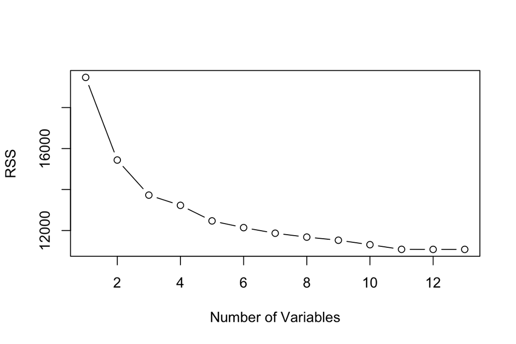

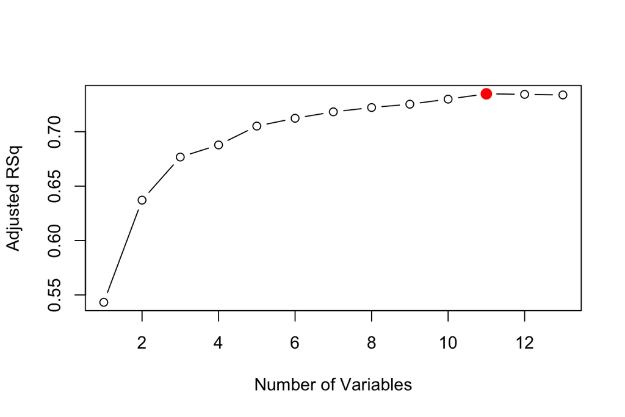

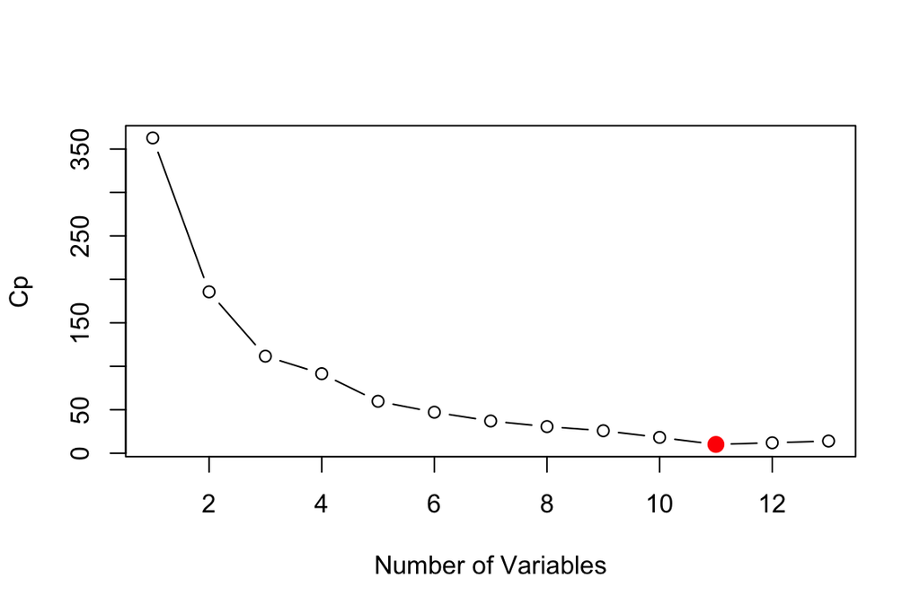

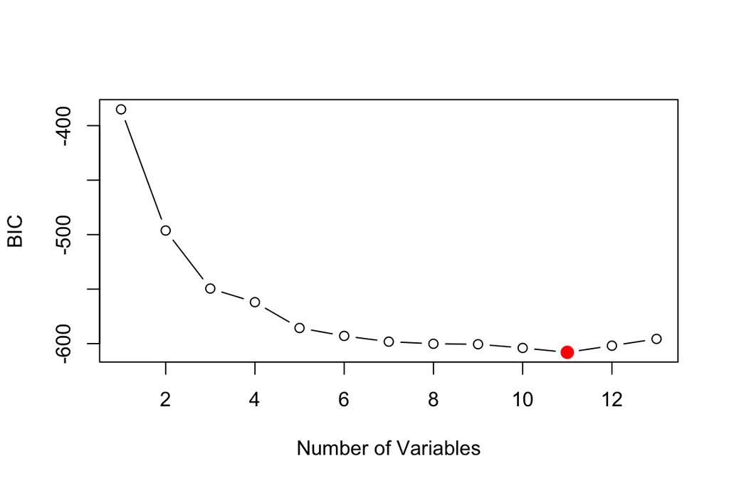

```r
plot(reg.s$rss, xlab = "Number of Variables", ylab = "RSS", type = "b")

plot(reg.s$adjr2, xlab = "Number of Variables", ylab = "Adjusted RSq", type = "b")
best_adj_r2 = which.max(reg.s$adjr2)
points(best_adj_r2, reg.s$adjr2[best_adj_r2],
       col = "red",cex = 2, pch = 20)

plot(reg.s$cp, xlab = "Number of Variables", ylab = "Cp", type = 'b')
best_cp = which.min(reg.s$cp)
points(best_cp, reg.s$cp[best_cp],
       col = "red", cex = 2, pch = 20)

plot(reg.s$bic, xlab = "Number of Variables", ylab = "BIC", type = 'b')
best_bic = which.min(reg.s$bic)
points(best_bic, reg.s$bic[best_bic],
       col = "red", cex = 2, pch = 20)
```